# Hockey Match Report

Analyst’s Diary Match Report

# Switzerland vs Sweden

**2026 (see official game summary)**  
IIHF Ice Hockey World Championship 2026

Switzerland (SUI) 3:1 Sweden (SWE)

Report generated from a manually reconciled IIHF shot-chart dataset. Official score, shots on goal and blocked shots are separated from transparent location-based proxy metrics. Chronological metrics are excluded because the source does not contain reliable event time or order.

Prepared by Antonin Kremenak

# Executive summary

Final score

SUI: 3 | SWE: 1

Shots on goal

SUI: 32 | SWE: 22

Validated attempts

SUI: 60 | SWE: 54

High-danger chances

SUI: 15 | SWE: 7

# 1. Match overview

Official match results are shown alongside validated shot-chart totals and clearly labelled spatial proxy metrics.

**Key metrics: Switzerland vs Sweden**

Official values and validated location-based shot-chart metrics

| Metric | SUI | SWE |
| --- | --- | --- |
| Validated shot-chart attempts | 60.00 | 54.00 |
| Corsi attempts | 60.00 | 54.00 |
| Fenwick attempts | 45.00 | 41.00 |
| Scoring chances | 39.00 | 26.00 |
| High-danger chances | 15.00 | 7.00 |
| Shot Quality Index | 4.80 | 3.15 |

**Validated input:** all 114 shot-chart events reconcile to period × team × result control totals.

# 2. Shot maps and spatial overview

Shot maps show where attempts came from, how dangerous they were spatially, and how shot locations changed across periods.

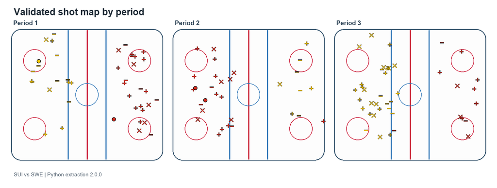

# 3. Shot quality and territorial battle

This section moves from simple shot counts to spatial pressure: location quality, offensive-zone density and period-by-period territorial advantage.

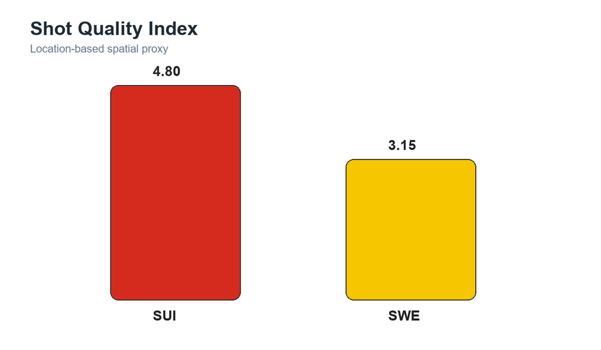

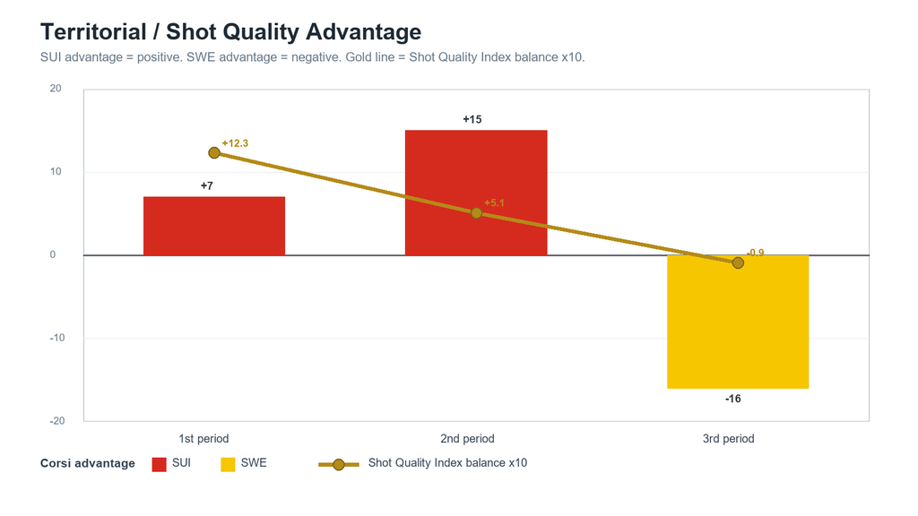

# 4. Offensive-zone density

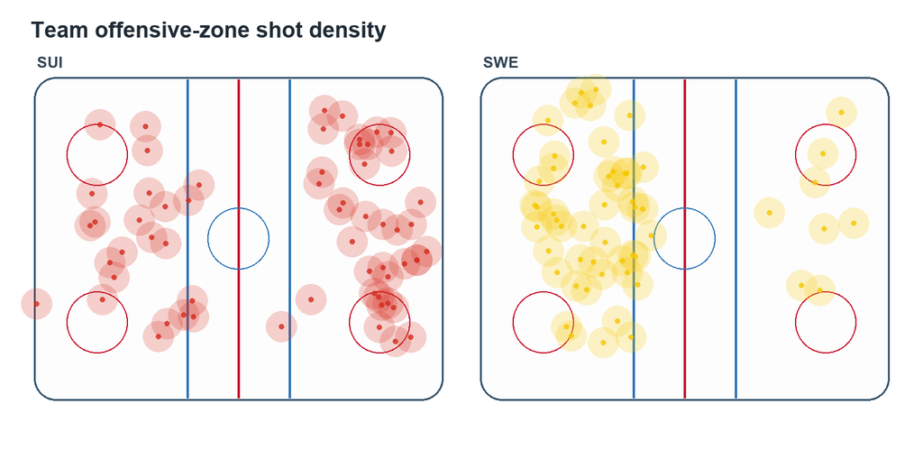

# 5. Advanced insider layer

The following metrics are proxy-based insider indicators built from the available shot-location sample. They are useful for storytelling, but they are not a substitute for full play-by-play or tracking data.

Metric legend

**Percentages:** share of all validated shot-chart attempts by the team. Spatial categories can overlap, so the columns are not expected to sum to 100%.

**High danger / HDC:** attempt within 25 feet of the goal and no more than 22 feet from the centre line.

**Middle lane:** attempt no more than 12 feet from the centre line.

**Net front:** attempt from the deep central area (at least 82 feet into the attacking direction and within 12 feet of the centre line).

**Slot:** attempt from the inner-slot area (68–92 feet into the attacking direction and within 18 feet of the centre line).

**Perimeter:** attempt at least 22 feet from the centre line or from the point side of the offensive zone.

**Point shots:** attempts taken less than 45 feet into the attacking direction.

**Validated SOG:** goals plus saved shots in the manually reviewed shot-chart dataset.

**Chances:** all medium- and high-danger attempts. **HDC** includes only high-danger attempts.

**SQI:** Shot Quality Index, a location proxy weighted 0.18 / 0.07 / 0.02 for high / medium / low-danger attempts; it is not a trained expected-goals model.

**Goals / …:** goals divided by the named denominator. Goals / SQI is a descriptive finishing proxy, not an xG-overperformance estimate.

**Shot-style profile**

Share of each team's validated shot-chart attempts

| Team | High danger | Middle lane | Net front | Perimeter | Point shots | Slot |
| --- | --- | --- | --- | --- | --- | --- |
| SUI | 25% | 45% | 8% | 50% | 30% | 27% |
| SWE | 13% | 46% | 2% | 63% | 48% | 11% |

**Finishing efficiency vs chance quality**

Conversion from the validated shot-chart dataset

| Team | Goals / HDC | Goals / chances | Goals / validated SOG | Goals / SQI | Goals / validated attempts |
| --- | --- | --- | --- | --- | --- |
| SUI | 20% | 8% | 9% | 0.62 | 5% |
| SWE | 14% | 4% | 4% | 0.32 | 2% |

# 6. Player layer

**Validated player shot leaders**

Player-level output from the manually reconciled IIHF shot chart

| Team | Player no. | Validated attempts | Validated shots on goal | Scoring chances | High-danger chances | Inner-slot shots | Net-front shots | Shot Quality Index | Avg shot distance |
| --- | --- | --- | --- | --- | --- | --- | --- | --- | --- |
| Switzerland | 22 | 6 | 4 | 5 | 4 | 4 | 3 | 0.81 | 18.8 |
| Sweden | 41 | 7 | 2 | 4 | 2 | 2 | 0 | 0.56 | 38.5 |
| Switzerland | 90 | 10 | 4 | 5 | 1 | 2 | 0 | 0.56 | 40.7 |
| Switzerland | 79 | 4 | 3 | 3 | 2 | 2 | 0 | 0.45 | 33.1 |
| Switzerland | 85 | 5 | 1 | 4 | 1 | 0 | 0 | 0.41 | 34.8 |
| Sweden | 91 | 5 | 2 | 4 | 1 | 0 | 0 | 0.41 | 37.7 |
| Sweden | 13 | 7 | 2 | 5 | 0 | 0 | 0 | 0.39 | 39.9 |
| Switzerland | 62 | 4 | 2 | 3 | 1 | 1 | 1 | 0.34 | 29.5 |
| Sweden | 16 | 4 | 3 | 3 | 1 | 1 | 1 | 0.34 | 30.7 |
| Switzerland | 28 | 5 | 2 | 4 | 0 | 0 | 0 | 0.30 | 44.9 |
| Switzerland | 17 | 3 | 2 | 2 | 1 | 1 | 0 | 0.27 | 34.8 |
| Sweden | 14 | 5 | 0 | 1 | 1 | 1 | 0 | 0.26 | 53.1 |

*Player numbers, shot results and coordinates were manually reconciled against the period × team × result totals printed in the IIHF shot chart. The source does not provide reliable game clock or event order, so rebound, momentum and score-state metrics are intentionally excluded.*

# Appendix: audit visuals

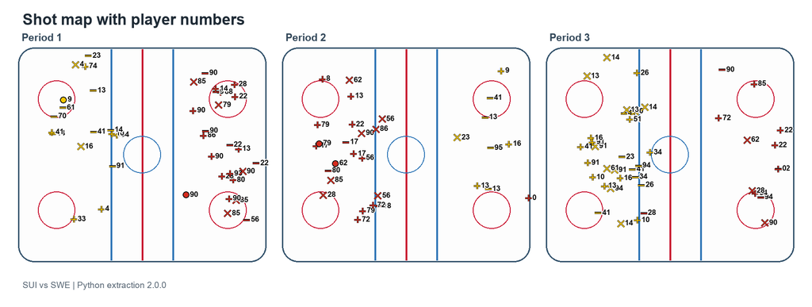

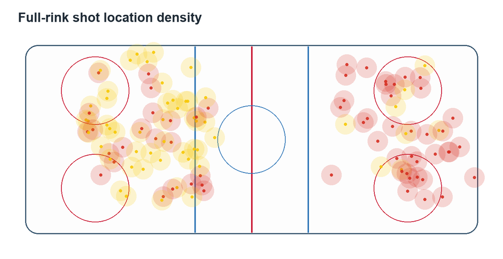

# 7. Validation, methodology and sources

**Publication validation**

114 manually reconciled shot-chart events; validated / official

| Team | Goals | Shots on goal | Blocked shots | Validated attempts | Validated Fenwick | Status |
| --- | --- | --- | --- | --- | --- | --- |
| SUI | 3 / 3 | 32 / 32 | 15 / 15 | 60 | 45 | OK |
| SWE | 1 / 1 | 22 / 22 | 13 / 13 | 54 | 41 | OK |

- **Official inputs:** final score, shots on goal and blocked shots.
- **Validated shot-chart inputs:** player number, shot result and spatial coordinates for all plotted attempts.
- **Proxy metrics:** scoring chances, high-danger chances, Shot Quality Index and style classifications are transparent rules based on shot location; they are not an official tracking feed or a trained expected-goals model.
- **Intentionally excluded:** momentum, rebounds, pressure windows and score-state behavior require chronological play-by-play data that the IIHF shot chart does not contain.
- **Source documents:** `game_summary.pdf`, `shots.pdf` and `lineups.pdf` from the IIHF match report package.
- **Official competition source:** https://www.iihf.com/en/events/2026/wm/schedule